# Section 0: R, dplyr, ggplot, and knitr

James Sundquist

8/29/2019

## Opening Files

Since we’ll be working in R Studio and not base R, let’s make sure `.r` and `.rmd` files open in the right program. For Macs, two-finger-click on a file of each type, select **Get Info**, and check **Open With**. If it’s not R Studio, be sure to click **Change All**. For Windows, the path is **Start > Settings > Apps > Default Apps**, and then “Choose default apps by file type.” Check to make sure that it worked.

Great! Now that we are in R Studio, let’s open a dataset. Go to the class Github page (https://github.com/shikhar46/quantmethods), and download the dataset `analysis_lottery_household.csv`. This is from one of the papers we talked about on Wednesday, and it has 13,414 observations of Southern households that had a child in Georgia between 1829 and 1833, when Cherokee lands were distributed to white citizens by lottery.

How do we open this dataset so that we can work with it? Base R has a `read.csv` function, but Professor Coppock strongly prefers that we use `read_csv`. To access that function, we need to go on two small detours to learn about packages and directories.

#### Packages

- A big part of the reason that R and R Studio are so great is that they are open-source, meaning that anyone can contribute code to make them better. One of the ways this happens is when people develop new tools, and then save them as a “package” for anyone to download and use.
- The thing to remember about packages is that the *first* time you want to use one, you have to download it from the internet using `install.packages`, and give the name in quotation marks. Every time *after* that, you load them up using `library` and **no** quotation marks. A little ideosyncratic, but just roll with it.
- The first package we’re going to install is actually a package of packages: the Tidyverse. It contains two packages that we will use frequently, `dplyr` and `ggplot2`, as well as the package that contains `read_csv`. Give the following code a try:

```r
install.packages("tidyverse")
library(tidyverse)
```

#### Directories

- R Studio needs to know where a file is in order to open it. There are two ways to do this: tell R Studio exactly what folder that file is in, or set the “working directory” (current folder) to the same location as our file. Let’s find out what folder R Studio is working in right now:

```r
getwd() #"Get working directory"
```

```
## [1] "/Users/james/Dropbox/504/sections"
```

- OK, that’s not the same as where my file is, which is in **/Users/james/Downloads**. Below, I’ll change the working directory to that folder. Note the quotation marks!

```r
setwd("/Users/james/Downloads")

# Advanced tip: the tilde (~) is a shortcut for your home directory, which for me is /Users/james. So I could also have run: setwd("~/Downloads")
```

Now we’re ready to open our dataset. I’m actually going to call it `ourdata`.

```r
ourdata <- read_csv("analysis_lottery_household.csv")
```

If I didn’t want to change my working directory, I could also run:

```r
ourdata <- read_csv("/Users/james/Downloads/analysis_lottery_household.csv")
```

## dplyr

Dplyr is a toolbox for manipulating data. Usually, the dataset we load into our computers are not ready for analysis, and we need to do a bit more work to get it the way we want. People use an interesting variety of verbs for this kind of work: tidying, cleaning, wrangling, etc.

Dplyr is a set of verbs (functions) that perform the basic tasks of data wrangling.

- `filter` returns *rows* of the dataset that match whatever logical conditions you set.
- `select` returns *columns* of the dataset that match whatever logical conditions you set.
- `rename` does exactly what it sounds like: it renames a variable.
- `mutate` creates a new variable

Let’s try them out on our dataset:

```r
#filter(data, conditions)
filter(ourdata, state=="Florida" & hh_size > 10)
```

```
## # A tibble: 69 x 23
##    state county last_sdx_code frst_sdx_code hh_size treat treat1overN
##    <chr> <chr>  <chr>         <chr>           <int> <int>       <dbl>
##  1 Flor… ALACH… L0783         F656               13     0      0
##  2 Flor… ALACH… L0468         F024               13     0      0
##  3 Flor… ALACH… L0021         F351               11     0      0
##  4 Flor… ALACH… L0782         F077               11     0      0.5
##  5 Flor… ALACH… L0438         F376               11     0      0.0833
##  6 Flor… ALACH… L0448         F132               11     1      1
##  7 Flor… CALHO… L0512         F281               11     0      0
##  8 Flor… CALHO… L0297         F104               11     0      0
##  9 Flor… CALHO… L0955         F376               11     0      0
## 10 Flor… COLUM… L0093         F376               11     0      0
## # ... with 59 more rows, and 16 more variables: treatMoverN <dbl>,
## #   confdr_hh_count <int>, frac_confdr_count_men <dbl>,
## #   confdr_hh_count_1861 <int>, confdr_hh_binary_1861 <int>,
## #   frac_confdr_count_men_1861 <dbl>, confdr_hh_MoverN <dbl>,
## #   confdr_any_MoverN <dbl>, frac_confdr_MoverN_men <dbl>,
## #   children_size <int>, sons_size <int>, slaves_hh_count <dbl>,
## #   realprop_head <int>, realprop_hsum <int>, confdr_hh_binary <int>,
## #   battle_county <int>
```

```r
#select(data, which columns)
select(ourdata, children_size, sons_size)
```

```
## # A tibble: 13,414 x 2
##    children_size sons_size
##            <int>     <int>
##  1             7         3
##  2             8         6
##  3             1         0
##  4             6         4
##  5            10         8
##  6             6         3
##  7             6         5
##  8             4         1
##  9            10         5
## 10             2         1
## # ... with 13,404 more rows
```

```r
kids <- select(ourdata, children_size, sons_size)

#All columns EXCEPT battle_county:
select(ourdata, -battle_county)
```

```
## # A tibble: 13,414 x 22
##    state county last_sdx_code frst_sdx_code hh_size treat treat1overN
##    <chr> <chr>  <chr>         <chr>           <int> <int>       <dbl>
##  1 Flor… ALACH… L1257         F602               10     0           0
##  2 Flor… ALACH… L1599         F376               10     1           1
##  3 Flor… ALACH… L1134         F606                5     0           0
##  4 Flor… ALACH… L1105         F606               10     1           1
##  5 Flor… ALACH… L0783         F656               13     0           0
##  6 Flor… ALACH… L1234         F351                9     0           0
##  7 Flor… ALACH… L1518         F194                8     0           0
##  8 Flor… ALACH… L0498         F376                7     0           0
##  9 Flor… ALACH… L0468         F024               13     0           0
## 10 Flor… ALACH… L0988         F024                5     1           1
## # ... with 13,404 more rows, and 15 more variables: treatMoverN <dbl>,
## #   confdr_hh_count <int>, frac_confdr_count_men <dbl>,
## #   confdr_hh_count_1861 <int>, confdr_hh_binary_1861 <int>,
## #   frac_confdr_count_men_1861 <dbl>, confdr_hh_MoverN <dbl>,
## #   confdr_any_MoverN <dbl>, frac_confdr_MoverN_men <dbl>,
## #   children_size <int>, sons_size <int>, slaves_hh_count <dbl>,
## #   realprop_head <int>, realprop_hsum <int>, confdr_hh_binary <int>
```

```r
mutate(ourdata, no_sons = sons_size==0)
```

```
## # A tibble: 13,414 x 24
##    state county last_sdx_code frst_sdx_code hh_size treat treat1overN
##    <chr> <chr>  <chr>         <chr>           <int> <int>       <dbl>
##  1 Flor… ALACH… L1257         F602               10     0           0
##  2 Flor… ALACH… L1599         F376               10     1           1
##  3 Flor… ALACH… L1134         F606                5     0           0
##  4 Flor… ALACH… L1105         F606               10     1           1
##  5 Flor… ALACH… L0783         F656               13     0           0
##  6 Flor… ALACH… L1234         F351                9     0           0
##  7 Flor… ALACH… L1518         F194                8     0           0
##  8 Flor… ALACH… L0498         F376                7     0           0
##  9 Flor… ALACH… L0468         F024               13     0           0
## 10 Flor… ALACH… L0988         F024                5     1           1
## # ... with 13,404 more rows, and 17 more variables: treatMoverN <dbl>,
## #   confdr_hh_count <int>, frac_confdr_count_men <dbl>,
## #   confdr_hh_count_1861 <int>, confdr_hh_binary_1861 <int>,
## #   frac_confdr_count_men_1861 <dbl>, confdr_hh_MoverN <dbl>,
## #   confdr_any_MoverN <dbl>, frac_confdr_MoverN_men <dbl>,
## #   children_size <int>, sons_size <int>, slaves_hh_count <dbl>,
## #   realprop_head <int>, realprop_hsum <int>, confdr_hh_binary <int>,
## #   battle_county <int>, no_sons <lgl>
```

You can read MUCH more about dplyr in chapter 5 of *R for Data Science*, or at https://cran.r-project.org/web/packages/dplyr/vignettes/dplyr.html

#### Your turn!

Use dplyr to do the following tasks. Remember that each row is a household.

- Return only households that owned slaves.
- Make a new dataset called `ourdata2`, that is identical to `ourdata`, but drops the battle_county variable.
- Actually, that is still too many variables. Make it so that `ourdata2` only has: treat, fracfrac_confdr_count_men, slaves_hh_count, realprop_hsum, and no_sons.
- Some of these names are really long. That’s good practice, because the names are clear that way, but let’s shorten some of them. In `ourdata2`, rename frac_confdr_count_men as frac_confdr (the percentage of household males who fought for the Confederacy). Also rename slaves_hh_count as slaves, and realprop_hsum as real_property (the value of real estate held by the family).
- Make a new variable called slaves_binary that takes the value of 1 if the household owned any slaves, and 0 otherwise.

#### group_by( ) and summarise( )

There are two more dplyr verbs that are frequently used together. `group_by` splits the data into subgroups, and `summarise` allows you to calculate something about each group. For instance, let’s check to see how family size varied by state:

```r
by_state <- group_by(ourdata, state)
summarise(by_state, avg_num_kids = mean(children_size))
```

```
## # A tibble: 11 x 2
##    state          avg_num_kids
##    <chr>                 <dbl>
##  1 Alabama                4.79
##  2 Arkansas               5.03
##  3 Florida                4.56
##  4 Georgia                4.44
##  5 Louisiana              4.72
##  6 Mississippi            4.75
##  7 North Carolina         4.44
##  8 South Carolina         4.52
##  9 Tennessee              4.29
## 10 Texas                  4.35
## 11 Virginia               4
```

That’s sort of cool, but instead of listing the states alphabetically, let’s list them by the average number of kids. For this, we’ll need our final dplyr verbs: `arrange` and `desc( )`.

```r
kids_by_state <- summarise(by_state, avg_num_kids = mean(children_size))
arrange(kids_by_state, desc(avg_num_kids))
```

```
## # A tibble: 11 x 2
##    state          avg_num_kids
##    <chr>                 <dbl>
##  1 Arkansas               5.03
##  2 Alabama                4.79
##  3 Mississippi            4.75
##  4 Louisiana              4.72
##  5 Florida                4.56
##  6 South Carolina         4.52
##  7 North Carolina         4.44
##  8 Georgia                4.44
##  9 Texas                  4.35
## 10 Tennessee              4.29
## 11 Virginia               4
```

#### The Pipe: %>%

Dplyr verbs work well together. Sometimes, you don’t want to work through one step at a time; you want to do multiple steps at once. In the bad old days, people wrote code this way: f(g(x)), where you do function G of object x, before doing function F of the result. This could get very confusing as the nested parentheses grew deeper. Furthermore, we read from left to right, not inside out. The dplyr philosophy says that we should write: `x %>% g() %>% f()`. Translation: take X, G it, then F it. Much more readable! The `%>%` symbol is called the “pipe”, and it passes arguments from left to right. You can either type it manually, or use `CMD + SHIFT + M` on Macs, or `CNTRL + SHIFT + M` on PCs.

Example: Among those who did not own real estate, did families with slaves still send their men to fight at a higher rate?

```r
# Note that by specifying our data at the outset, we can skip the first argument of these functions
ourdata2 %>%
  filter(real_property==0) %>%
  group_by(slaves_binary) %>%
  summarise(avg_participation_rate = mean(frac_confdr))
```

```
## # A tibble: 2 x 2
##   slaves_binary avg_participation_rate
##   <lgl>                          <dbl>
## 1 FALSE                          0.677
## 2 TRUE                           0.735
```

Stylistic note: after every pipe, start a new line!

#### Your turn!

- Chain together dplyr commands using `%>%` to answer the question: excluding households with no sons, how did average real estate holdings vary by treatment status? (Treat = 1 means they won land in the lottery , treat = 0 means they did not.)

## ggplot

ggplot can help you make beautiful figures. Personally, I don’t think the grammar makes as much sense as dplyr does, but you only have to remember a basic recipe: `ggplot(name of dataset, aes(x = something, y = something else)) + type of plot you want`

Types of plots in ggplot are called geoms. Let’s look at some common ones. I’m going to only use the data from Alabama, because it is easier to see 2000 points than 13,000 points.

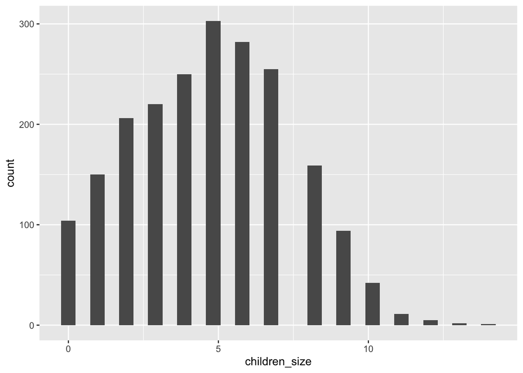

```r
al_data <- ourdata %>% filter(state=="Alabama")

# A histogram. You can change the number of "bins" if you so desire.
ggplot(al_data, aes(x = children_size)) + geom_histogram()
```

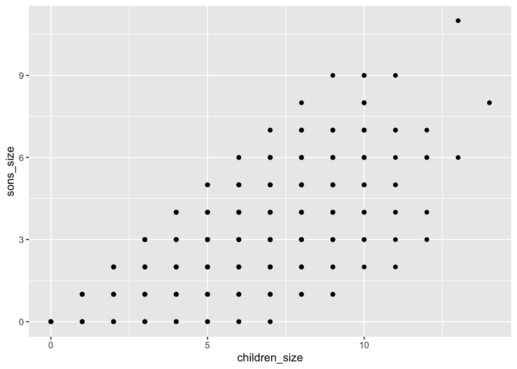

```r
# A scatterplot.
ggplot(al_data, aes(x = children_size, y = sons_size)) + geom_point()
```

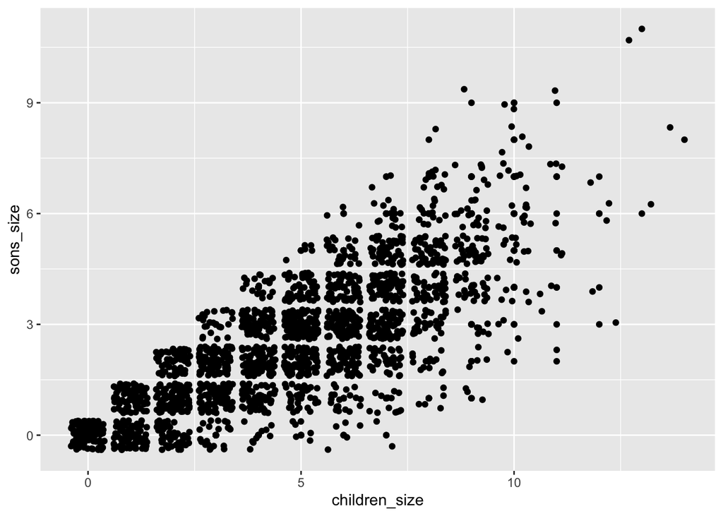

```r
# Adding the "jitter" geom adds some random noise to the points, so that they are not all on top of one another.
ggplot(al_data, aes(x = children_size, y = sons_size)) + geom_point() + geom_jitter()
```

Note how you can use + signs to slowly build up a plot.

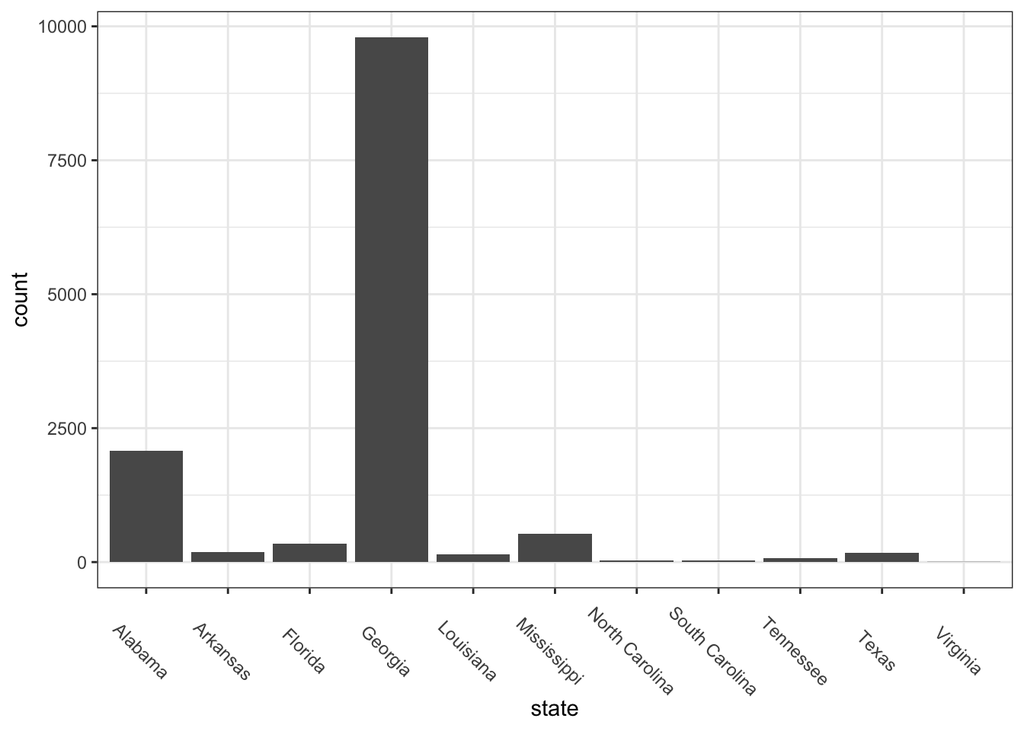

```r
fig1 <- ggplot(ourdata2, aes(x = state))
fig1 <- fig1 + geom_bar()
fig1 <- fig1 + theme_bw()
fig1 + theme(axis.text.x = element_text(angle = -45)) #rotate labels
```

#### Coefficient Plots

Take a look at Table 7/Figure 6 of this paper: https://www.princeton.edu/~jkastell/Tables2Graphs/graphs.pdf

Coef plots are **way** easier to interpret than tables of regression output. Let’s make one with our dataset. First we’ll need to load a package and run a model.

```r
library(estimatr)
```

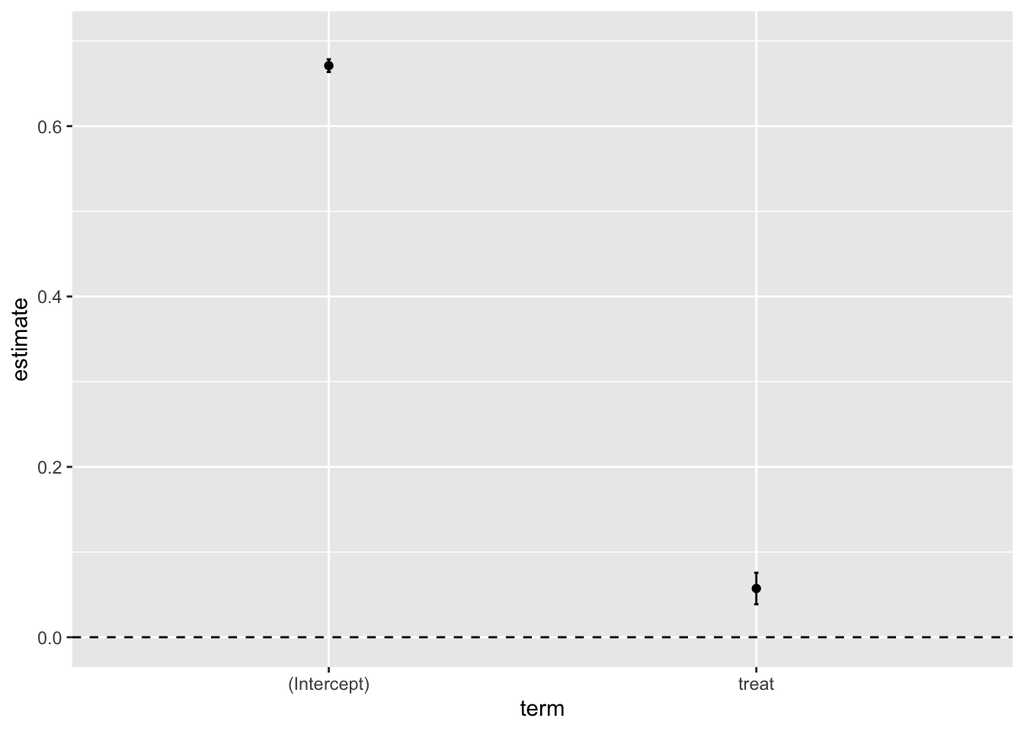

```r
model1 <- lm_robust(formula = frac_confdr_count_men ~ treat, data = ourdata)
out1 <- tidy(model1)

fig2 <- ggplot(out1, aes(x = term, y = estimate))
fig2 <- fig2 + geom_point() + geom_abline(slope = 0, intercept = 0, lty = 2)
fig2 <- fig2 + geom_errorbar(aes(ymin = estimate - 1.96*std.error, ymax = estimate + 1.96*std.error), width = .01)
fig2 + expand_limits(y = c(0, .7))
```

The figure above uses a few different geoms: ab_line to draw a dashed line at y = 0, point to make points, and errorbar to show a 95% confidence interval.

#### Your turn!

Install the package `nycflights13` and then load it from the library. It won’t show up in the upper-right box, but the data is there, in a tibble called `flights`. Take a look at the data with `View(flights)`. Try to make a few plots.

### Faceting

Just as we `group_by` when analyzing data statistically, so might we want to break the analysis into small subgroups when we examine the data visually. In the Tidyverse, this is called faceting. Beyond the Tidyverse, you might hear them called “small multiples.” To facet by a variable, add this to your code: `+ facet_wrap(~ variable)`. Let’s see how the distribution of flight times varied by airport.

```r
library(nycflights13)
```

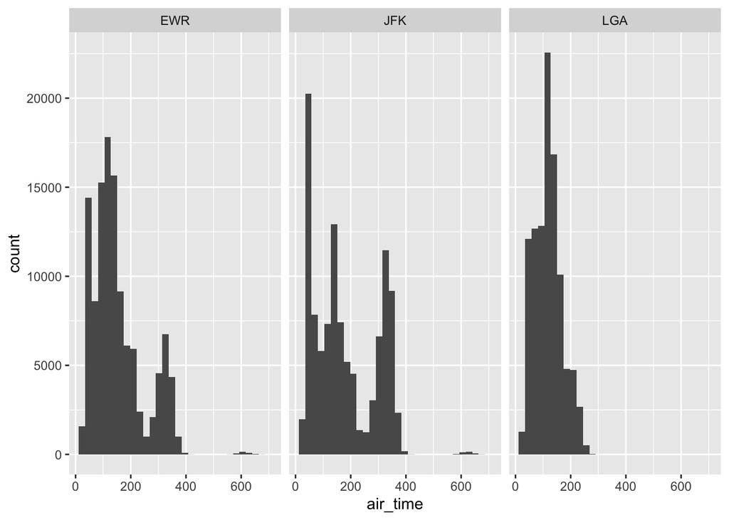

```r
ggplot(flights, aes(x = air_time)) + geom_histogram() + facet_wrap(~ origin)
```

## knitr and LaTeX

So you’ve done all your analysis, your results are robust, and your evidence is beautiful. Time to share it with the world!

If you’re writing lots of code, it’s best to compile your results in R Markdown. (This document was created in R Markdown.) When it comes time to write a paper, and you only need to include a few figures, it might be time to use `LaTeX`.

To write in R Markdown, we will first install a package called `knitr`. (You should already be a pro at installing packages!) However, we are not going to open it in from the library. Instead, go all the way to the top of the screen and click on **File > New File > R Markdown**.

A new R Markdown file should pop up, full of helpful hints. Click on the **Knit** button on the top of the screen to compile it into a pdf. Congratulations! You’re ready to begin doing problem sets!